# hw6

```python
from rdkit import Chem
from rdkit.Chem import AllChem
from rdkit import RDConfig
from rdkit.Chem.Draw import IPythonConsole
from rdkit.Chem import Draw
import numpy as np
from IPython.display import display,Image
```

Посчитаем данные для топологии

```python
mol=Chem.MolFromSmiles('CC')
AllChem.Compute2DCoords(mol)
m3d=Chem.AddHs(mol)
Chem.AllChem.EmbedMolecule(m3d)
AllChem.MMFFOptimizeMolecule(m3d,maxIters=500,nonBondedThresh=200 )
```

```
0
```

```python
## связи
bonds = m3d.GetBonds()
for i,b in enumerate(bonds):
    print(b.GetBeginAtomIdx() + 1 , b.GetEndAtomIdx() + 1, 1)
```

```
1 2 1
1 3 1
1 4 1
1 5 1
2 6 1
2 7 1
2 8 1
```

```python
## углы
for b1 in m3d.GetBonds():
    for b2 in m3d.GetBonds():
        if b1.GetBeginAtomIdx() == b2.GetBeginAtomIdx() and b1.GetIdx() != b2.GetIdx():
            print(b1.GetEndAtomIdx() + 1 , b1.GetBeginAtomIdx() + 1, b2.GetEndAtomIdx() + 1, 1)
```

```
2 1 3 1
2 1 4 1
2 1 5 1
3 1 2 1
3 1 4 1
3 1 5 1
4 1 2 1
4 1 3 1
4 1 5 1
5 1 2 1
5 1 3 1
5 1 4 1
6 2 7 1
6 2 8 1
7 2 6 1
7 2 8 1
8 2 6 1
8 2 7 1
```

```python
## dihedrals
angs = set()
for b1 in m3d.GetBonds():
    for b2 in m3d.GetBonds():
        for b3 in m3d.GetBonds():
            if b1.GetBeginAtomIdx() == b2.GetBeginAtomIdx() and b2.GetEndAtomIdx() == b3.GetBeginAtomIdx() and b1.GetIdx() != b2.GetIdx():
                angs.add((b1.GetEndAtomIdx() + 1 , b1.GetBeginAtomIdx() + 1, b2.GetEndAtomIdx() + 1, b3.GetEndAtomIdx() + 1, 1))
for elem in angs:
    print(*elem)
```

```
4 1 2 8 1
5 1 2 7 1
5 1 2 8 1
3 1 2 6 1
3 1 2 8 1
4 1 2 7 1
5 1 2 6 1
3 1 2 7 1
4 1 2 6 1
```

```python
%%bash
cat /usr/share/gromacs/top/oplsaa.ff/atomtypes.atp
```

[output not shown]

Внесем нужные изменения в топологию

Скачаем файлы

```python
! mkdir data6
! wget http://kodomo.fbb.msu.ru/FBB/year_08/term6/be.mdp -O data6/be.mdp
! wget http://kodomo.fbb.msu.ru/FBB/year_08/term6/vr.mdp -O data6/vr.mdp
! wget http://kodomo.fbb.msu.ru/FBB/year_08/term6/nh.mdp -O data6/nh.mdp
! wget http://kodomo.fbb.msu.ru/FBB/year_08/term6/an.mdp -O data6/an.mdp
! wget http://kodomo.fbb.msu.ru/FBB/year_08/term6/sd.mdp -O data6/sd.mdp
```

```python
! wget https://kodomo.fbb.msu.ru/FBB/year_08/term6/etane.gro
```

```python
%%bash
for fn in be vr nh an sd; do
    SECONDS=0
    grompp -f "$fn.mdp" -c etane.gro -p et.top -o "et_$fn.tpr" > /dev/null 2>&1
    mdrun -deffnm "et_$fn" -v -nt 1 > /dev/null 2>&1
    echo 2 | trjconv -f "et_$fn.trr" -s "et_$fn.tpr" -o "et_$fn.pdb" > /dev/null 2>&1
    duration=$SECONDS
    echo "$fn $duration seconds"
done;
```

```
be 6 seconds
vr 7 seconds
nh 6 seconds
an 6 seconds
sd 8 seconds
```

Velocity rescale - в основном вращается вокруг С-С, но также и по другим осям, визуализация получилась довольно приятная

```python
from IPython.display import Video
Video('vr.mpeg', width=320, height=256)
```

[video not shown]

Метод Андерсена - практически стоит на месте, слегка дергается.

```python
Video('an.mpeg', width=320, height=256)
```

[video not shown]

Берендсена - похож на VR

```python
Video('be.mpeg', width=320, height=256)
```

[video not shown]

Нуз-Хувер - крутится вокруг связи С-С.

```python
Video('nh.mpeg', width=320, height=256)
```

[video not shown]

Стохастическая динамика - хаотично вращается.

```python
Video('sd.mpeg', width=320, height=256)
```

[video not shown]

Сравним потенциальную и кинетическую энергию

```python
%%bash
for fn in be vr nh an sd; do
    echo 10 | g_energy -f "et_$fn.edr" -o "et_$fn.xvg" -xvg none
done;
```

```python
import numpy as np
import matplotlib.pyplot as plt

def plot_en(fn):
    a = np.loadtxt(fn)
    t = a[:,0]
    y = a[:, 1]
    plt.plot(t, y)
```

Построим графики для разных методов

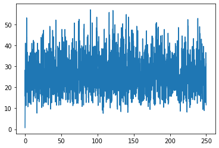

```python
plot_en("et_vr.xvg")
```

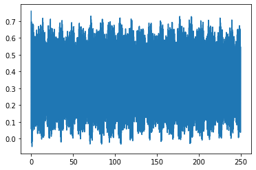

```python
plot_en("et_an.xvg")
```

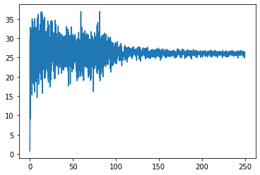

```python
plot_en("et_be.xvg")
```

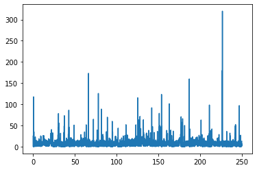

```python
plot_en("et_nh.xvg")
```

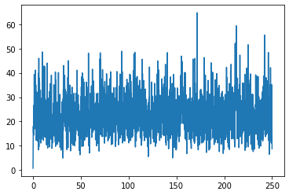

```python
plot_en("et_sd.xvg")
```

Как видим, в методах Velocity rescale и стохастической молекулярной динамики графики получились довольно похожи, энергия колеблется около одного значения, разброс не очень большой. У метода Андерсена разбрс совсем маленький, но значение энергии подозрительно меньше остальных методоы. У Нуза-Хувера лишком большой разброс, от 0 до более, чем 300, у Берендсена амплитуда постепенно уменьшается.

```python
%%writefile b.ndx

[ b ]
1 2
```

```
Overwriting b.ndx
```

```python
%%bash
for fn in be vr nh an sd; do
    g_bond -f "et_$fn.trr" -s "et_$fn.tpr" -o "bond_$fn.xvg" -n b.ndx -xvg none
done;
```

```python
def plot_bond(fn):
    a = np.loadtxt(fn)
    plt.figure(figsize=(7, 4))
    plt.grid(True)
    plt.hist(a[:, 1])
    plt.show()
```

Velocity rescale

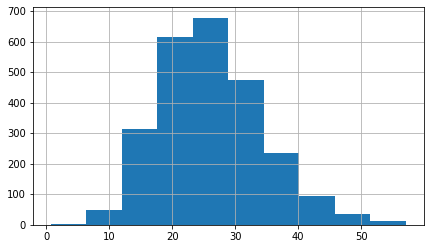

```python
plot_bond("et_vr.xvg")
```

Андерсен

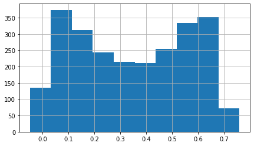

```python
plot_bond("et_an.xvg")
```

Берендсен

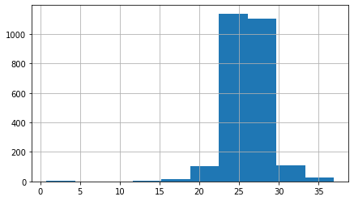

```python
plot_bond("et_be.xvg")
```

Нуз-Хувер

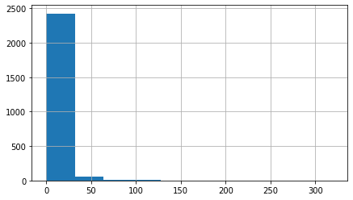

```python
plot_bond("et_nh.xvg")
```

Стохастическая динамика

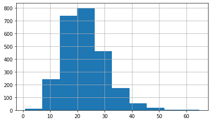

```python
plot_bond("et_sd.xvg")
```

Видим, что наиболее близкие результаты к распределению Больцмана имеет Velocity rescale, также он показал хорошие результаты про анализе энергии.

Метод Андерсена дал совсем не похожий на распределение Больцмана график, в центре "выемка".

Метод Бендерсена достаточно похож на правду.

Стохастическая динамика - хороший график, напоминает VR.

Теперь построим таблицу времени работы алгоритмов в секундах (получено выше)

```python
import pandas as pd

pd.DataFrame({"name":["be", "vr", "nh", "an", "sd"], "duration (s)": [6, 7, 6, 6, 8]})
```

|  | name | duration (s) |
| --- | --- | --- |
| 0 | be | 6 |
| 1 | vr | 7 |
| 2 | nh | 6 |
| 3 | an | 6 |
| 4 | sd | 8 |

Отличия по времени незначительные, все методы отработали за несколько секунд.